# Support Vector Machines

## Apply Gaussian RBF Kernel

Another technique to solve nonlinear problem is to add features from similarity function. It works based on measuring how much each instance is similar to a particular landmark. The function that measures similarity is the Gaussian Radial Basis Function (RBF) (Aurélien Géron, 2019).

The following code shows how to apply the Gaussian RBF kernel using the SVC class:

```python
np.random.seed(32)
rbf_kernel_svm_clf = Pipeline([("scaler", StandardScaler()), ("svm_clf", SVC(kernel="rbf", gamma=7, C=0.01))])
rbf_kernel_svm_clf.fit(x1, y1)
```

```
Pipeline(steps=[('scaler', StandardScaler()),
                ('svm_clf', SVC(C=0.01, gamma=7))])
```

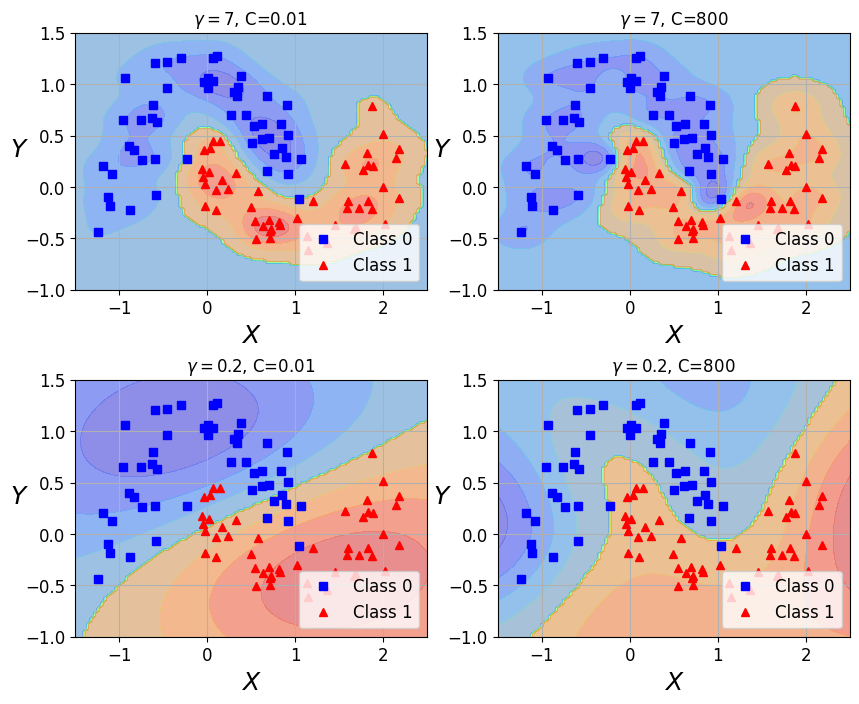

```python
font = {'size'   : 12}
matplotlib.rc('font', **font)
fig, axs = plt.subplots(figsize=(10, 8), dpi= 100, facecolor='w', edgecolor='k')
fig.subplots_adjust(hspace = 0.35, wspace=0.2)

ax1=plt.subplot(2,2,1)

predictions(rbf_kernel_svm_clf, [-1.5, 2.5, -1, 1.5])
moon_dataset(x1, y1, [-1.5, 2.5, -1, 1.5])
plt.title(r'$\gamma=7$'+', C=0.01 ', fontsize=12)

ax2=plt.subplot(2,2,2)
np.random.seed(32)
rbf_kernel_svm_clf = Pipeline([("scaler", StandardScaler()), ("svm_clf", SVC(kernel="rbf", gamma=7, C=800))])
rbf_kernel_svm_clf.fit(x1, y1)

predictions(rbf_kernel_svm_clf, [-1.5, 2.5, -1, 1.5])
moon_dataset(x1, y1, [-1.5, 2.5, -1, 1.5])
plt.title(r'$\gamma=7$'+', C=800 ', fontsize=12)

ax3=plt.subplot(2,2,3)
np.random.seed(32)
rbf_kernel_svm_clf = Pipeline([("scaler", StandardScaler()), ("svm_clf", SVC(kernel="rbf", gamma=0.2, C=0.01))])
rbf_kernel_svm_clf.fit(x1, y1)

predictions(rbf_kernel_svm_clf, [-1.5, 2.5, -1, 1.5])
moon_dataset(x1, y1, [-1.5, 2.5, -1, 1.5])
plt.title(r'$\gamma=0.2$'+', C=0.01 ', fontsize=12)

ax4=plt.subplot(2,2,4)
np.random.seed(32)
rbf_kernel_svm_clf = Pipeline([("scaler", StandardScaler()), ("svm_clf", SVC(kernel="rbf", gamma=0.2, C=800))])
rbf_kernel_svm_clf.fit(x1, y1)

predictions(rbf_kernel_svm_clf, [-1.5, 2.5, -1, 1.5])
moon_dataset(x1, y1, [-1.5, 2.5, -1, 1.5])
plt.title(r'$\gamma=0.2$'+', C=800 ', fontsize=12)
plt.show()
```

There are several options to choose for classification with SVM but **you should always try the linear kernel first because it is much faster especially for large training set. You can apply Gaussian RBF kernel if the training set is not too large**. It is recommended to use cross-validation to make sure if computational cost is fine to run Gaussian RBF kernel.